# Simulation Study on Climate Adaptation using PCA

#### Parallel Coordinates Plot

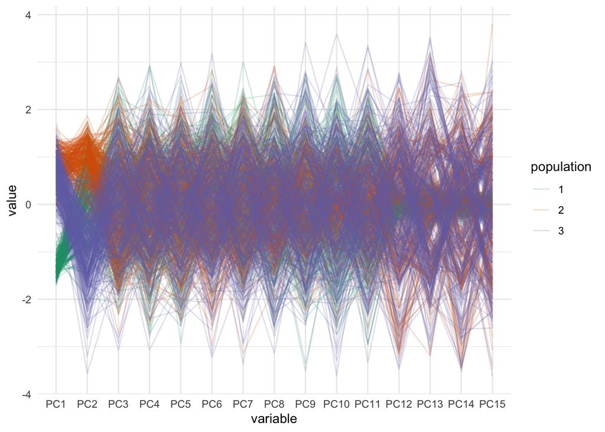

```r
# parallel coordinates plot
scores_tree_pca %>%
  as.data.frame() %>%
  mutate(population = as.factor(tree_pcadata$population)) %>%
  ggparcoord(columns = 1:15, groupColumn = 'population', alpha = 0.2) +
  theme_minimal() +
  scale_color_brewer(palette = 'Dark2')
```

#### Loadings Plot

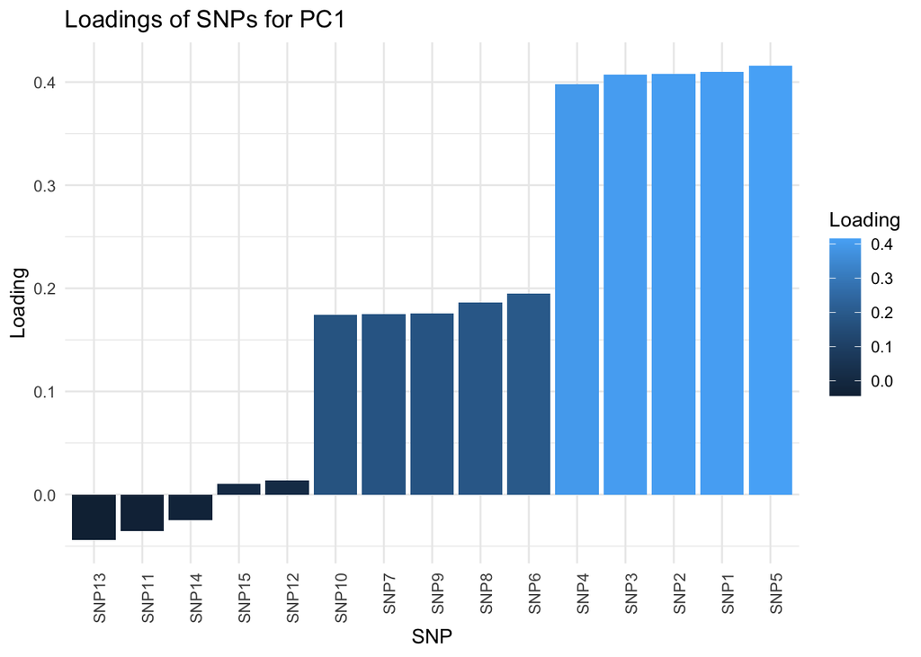

```r
pc1_loadings <- tree_pca_out$rotation[, 1]


loadings_df <- data.frame(
  SNP = rownames(tree_pca_out$rotation),  # SNP names
  Loading = pc1_loadings             # Loadings for PC1
)

ggplot(loadings_df, aes(x = reorder(SNP, Loading), y = Loading, fill = Loading)) +
  geom_bar(stat = "identity") +
  labs(x = "SNP", y = "Loading", title = "Loadings of SNPs for PC1",
    fill = "Loading"
  ) +
  theme_minimal() +
  theme(axis.text.x = element_text(angle = 90, hjust = 1))
```

**WHich SNPs contribute the most to PC1?**

#### Variance Explained

What proportion of total variance each PC explains, we can create what’s known as a scree plot. The code chunk below calculates the proportion of variance explained.

```r
# calculate proportion of variance explained
tree_total_var <- sum(var_tree_pca)
tree_pve <- var_tree_pca/tree_total_var
```

#### Visualizing the Proportion of variance explained compares across the PCs

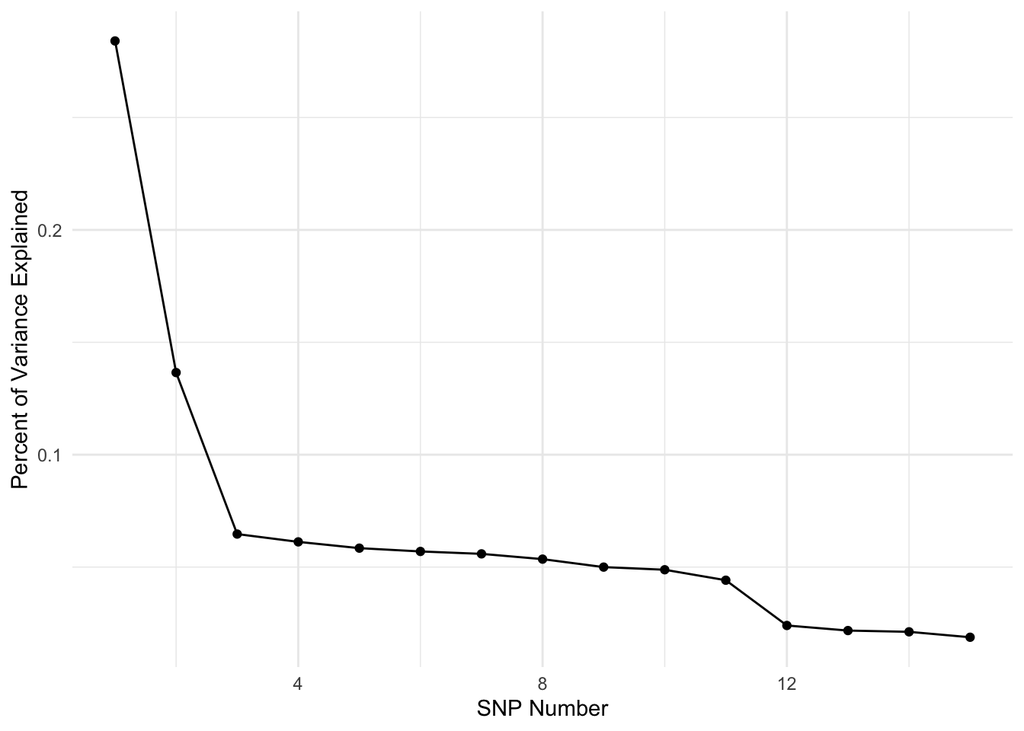

```r
# SNPs
tree_pve %>%
  as.data.frame() %>%
  mutate(index = seq_len(length(var_tree_pca))) %>%
  ggplot(aes(x = index, y = tree_pve)) +
  geom_point() +
  geom_line() +
  labs(x = 'SNP Number', y = 'Percent of Variance Explained') +
  theme_minimal()
```

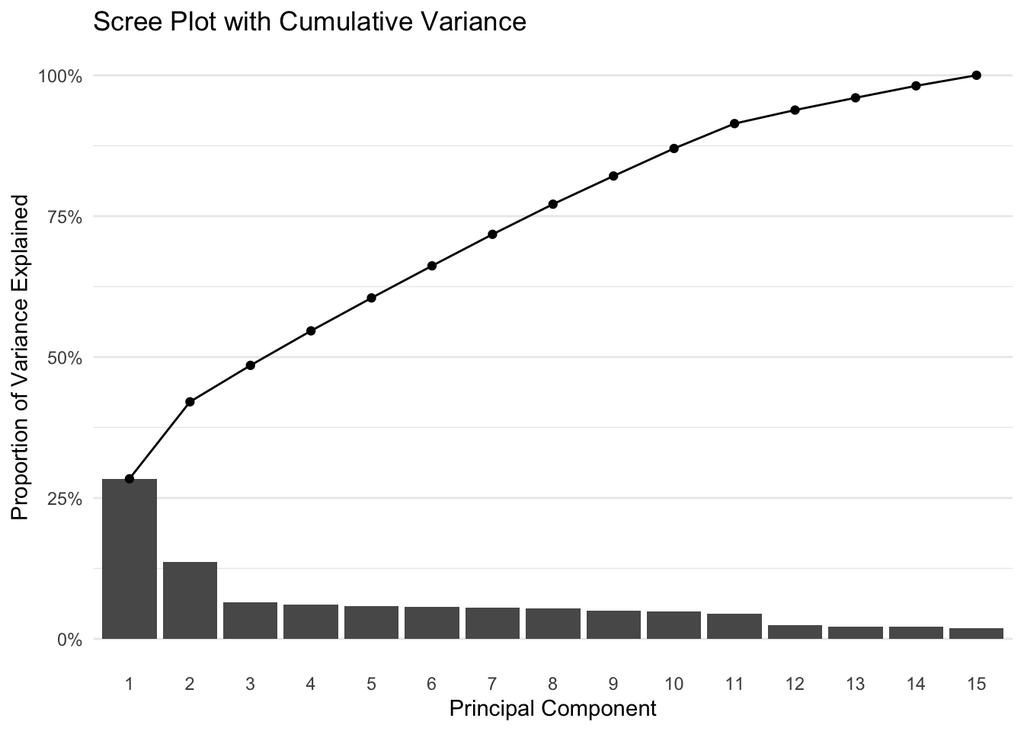

```r
# PCs

# Create data frame for plotting
tree_variance_df <- data.frame(
  PC = factor(1:length(tree_pve)),
  Individual = tree_pve,
  Cumulative = cumsum(tree_pve)
  )

# Create scree plot
ggplot(tree_variance_df, aes(x = PC)) +
  geom_col(aes(y = Individual)) +
  geom_point(aes(y = Cumulative)) +
  geom_line(aes(y = Cumulative, group = 1)) +
  scale_y_continuous(labels = scales::percent) +
  labs(x = "Principal Component", y = "Proportion of Variance Explained", title = "Scree Plot with Cumulative Variance") +
  theme_minimal() +
  theme(panel.grid.major.x = element_blank())
```

## What happens if we would have not realized about the confounding on our data?

### Omitted Variable Bias

Reminder: Bias is how long or how far (on average) we are to the “truth”.

In this context we are talking about parameters, so…

If $\hat{\theta}$ estimates $\theta$, bias is $E[\hat{\theta}] - \theta$.

When confounding variables are omitted:  
- Estimates become biased ($E[\hat{\beta} \neq \beta$)  
- Variance estimates are also distorted

#### Expected Value Rules (Probability Foundations):

For random variables $X,Y$ and constants $a,b$ (aka Linearity of Expectation):

$$\begin{aligned}
E[X + Y] &= E[X] + E[Y] \\
E[aX] &= aE[X] \\
E[b] &= b
\end{aligned}$$

#### Proof: OLS Unbiasedness (Correct Model)

**Model**: $y = X\beta + \epsilon$, where $E[\epsilon] = 0$  
**Estimator**: $\hat{\beta} = (X^TX)^{-1}X^Ty$

$$\begin{align*}
E[\hat{\beta}] &= E[(X^TX)^{-1}X^Ty] \\
&= (X^TX)^{-1}X^TE[y] \quad \text{(Linearity of expectation)} \\
&= (X^TX)^{-1}X^T X\beta \quad \text{(Since } E[y] = X\beta) \\
&= \beta \quad
\end{align*}$$

#### Proof: OLS Bias (Omitted Variable) <- What would happen to us if we don’t think about Elevation!!!

**True Model**: $y = X\beta + Z\gamma + \epsilon$  
**Fitted Model**: $y = X\beta + \epsilon^*$ (omits $Z$)

### References:

- National Academies of Sciences, Engineering, and Medicine. 2023. Using Population Descriptors in Genetics and Genomics Research: A New Framework for an Evolving Field. Washington, DC: The National Academies Press. https://doi.org/10.17226/26902.
- Bryc, K., Durand, E. Y., Macpherson, J. M., Reich, D., & Mountain, J. L. (2015). The Genetic Ancestry of African Americans, Latinos, and European Americans across the United States. The American Journal of Human Genetics, 96(1), 37-53. https://doi.org/10.1016/j.ajhg.2014.11.010
- Novembre, J., Johnson, T., Bryc, K., Kutalik, Z., Boyko, A. R., Auton, A., Indap, A., King, K. S., Bergmann, S., Nelson, M. R., Stephens, M., & Bustamante, C. D. (2008). Genes mirror geography within Europe. Nature, 456(7218), 98-101. https://doi.org/10.1038/nature07331
- Price, A. L., Zaitlen, N. A., Reich, D., & Patterson, N. (2010). New approaches to population stratification in genome-wide association studies. Nature Reviews. Genetics, 11(7), 459–463. https://doi.org/10.1038/nrg2813
- Simonson, T. S., Yang, Y., Huff, C. D., Yun, H., Qin, G., Witherspoon, D. J., Bai, Z., Lorenzo, F. R., Xing, J., Jorde, L. B., Prchal, J. T., & Ge, R. (2010). Genetic Evidence for High-Altitude Adaptation in Tibet. Science, 329(5987), 72-75. https://doi.org/10.1126/science.1189406
- Stebbins, G. L. (1950). Variation and Evolution in Plants. Columbia University Press. https://doi.org/10.7312/steb94536
- Zheng, L., Gaire, N. P., & Shi, P. (2021). High-altitude tree growth responses to climate change across the Hindu Kush Himalaya. Journal of Plant Ecology, 14(5), 829-842. https://doi.org/10.1093/jpe/rtab035